# WP1: Simple View - Cross-validation

This script is used for split-half cross validation. It takes the final model selected from **WP1_SimpView_LPA_shape.Rmd** (developed on sub-sample A) and tests it on sub-sample B. For reassurance, we then take a model fitted to sub-sample (**WP1_SimpView_LPA_shape_B.Rmd**) and tests it on sub-sample A.

# Set-up

```r
# Specify packages
pkgs <- c("tidyverse", "MplusAutomation", "texreg", "kableExtra", "scales")

# Use groundhog package to load correct package versions
# if (!require("groundhog")) install.packages("groundhog")
# groundhog.day <- "2021-03-01"
# groundhog::groundhog.library(pkgs, groundhog.day)

# Or if not using groundhog package - load currently installed package versions separately (reproducibility not guaranteed)
invisible(lapply(pkgs, library, character.only = TRUE))
```

```r
# Create subdirectories for storing mplus scripts, data files, and output, if do not already exist
if(dir.exists("./mplus_models/")==FALSE){dir.create("./mplus_models/")}
if(dir.exists("./mplus_models/simpview/")==FALSE){dir.create("./mplus_models/simpview/")}
if(dir.exists("./mplus_models/simpview/shape")==FALSE){dir.create("./mplus_models/simpview/shape")}
if(dir.exists("./mplus_models/simpview/shape/crossval")==FALSE){dir.create("./mplus_models/simpview/shape/crossval")}
if(dir.exists("./mplus_models/simpview/shapeB")==FALSE){dir.create("./mplus_models/simpview/shapeB")}
if(dir.exists("./mplus_models/simpview/shapeB/crossval")==FALSE){dir.create("./mplus_models/simpview/shapeB/crossval")}
if(dir.exists("./mplus_models/simpview/final_model")==FALSE){dir.create("./mplus_models/simpview/final_model")}
if(dir.exists("../output/")==FALSE){dir.create("../output/")}
if(dir.exists("../output/figures")==FALSE){dir.create("../output/figures")}
if(dir.exists("../output/tables")==FALSE){dir.create("../output/tables")}
```

### Read in final model from exploratory sample

Read in selected model file that contains class assignment data, and data file of descriptive statistics. Merge and check.

```r
# Read in and extract class data
final_mod <- readModels(target = "./mplus_models/simpview/shape", filefilter = "lpa4_rerun_6class")  # final model file
```

### Load and prepare confirmatory subsample for Mplus

```r
data_B <- read.csv("../data/processed/WP1_data_subB.csv")  %>%        # ALSPAC data sub B
  dplyr::select(yp_id, cidB3153, age_m_f8, age_m_f9,
                nara_acc_raw_f9, read_word_raw_f9, read_nonw_raw_f9,  # reading accuracy variables
                nara_comp_raw_f9, wold_comp_raw_f8) %>%               # comprehension variables
  mutate(combAcc = read_word_raw_f9 + read_nonw_raw_f9) %>%           # create combined single item accuracy score
  select(-read_word_raw_f9, -read_nonw_raw_f9) %>%                    # remove other measures
  rename(naraComp = nara_comp_raw_f9,                                 # rename within mplus character limit
         naraAcc = nara_acc_raw_f9,
         woldComp = wold_comp_raw_f8,
         f8age = age_m_f8,
         f9age = age_m_f9) %>%
  mutate(yp_id = as.factor(yp_id))
```

### Extract factor scores from CFA model

The final model uses general ability factor scores as a covariate, so first need to extract these for subsample B.

```r
# Run single factor model (including age covariates & correlated residuals for comprehension measures)
m_cfa <- mplusObject(
  TITLE = "Confirmatory Factor Analysis - Extract factor scores;",
  ANALYSIS = "estimator = mlr; type = general;",
  MODEL = "f8age; f9age;
           G by combAcc naraAcc naraComp woldComp;
           woldComp with naraComp;
           combAcc naraAcc naraComp on f9age;
           woldComp on f8age;",
  VARIABLE = "idvariable = cidB3153;",
  OUTPUT = "sampstat; TECH1; TECH4; stdyx; modindices; ",
  PLOT = "TYPE = PLOT3;",
  usevariables = c("cidB3153", "naraComp", "naraAcc", "combAcc", "woldComp", "f8age", "f9age"),
  rdata = data_B,
  SAVEDATA = "FILE IS cfa_B.dat; SAVE = fscores;")

m_cfa_fit <- mplusModeler(m_cfa,
                           modelout = "./mplus_models/simpview/shape/crossval/cfa_B.inp",
                           check = TRUE, run = FALSE)
```

```
## The following lines are longer than 90 characters
## 4: FILE = "./mplus_models/simpview/shape/crossval/cfa_B_5d1661a61d02e40cc3ff92203e61da3c.dat";
```

```
## Mplus will ignore everything after the 90th character on a line.
## Consider breaking the line(s)
```

```r
# Inspect model output
cfa_out <- readModels(target = "./mplus_models/simpview/shape/crossval", filefilter = "cfa")
SummaryTable(cfa_out, keepCols = c("Title", "Parameters", "LL", "CFI", "TLI", "AIC", "BIC", "RMSEA_Estimate", "RMSEA_pLT05", "SRMR")) %>% kable("pipe")
```

| Title | Parameters | LL | CFI | TLI | AIC | BIC | RMSEA_Estimate | RMSEA_pLT05 | SRMR |
| --- | --- | --- | --- | --- | --- | --- | --- | --- | --- |
| Confirmatory Factor Analysis - Extract factor scores; | 24 | -56586.08 | 0.999 | 0.996 | 113220.2 | 113367.5 | 0.027 | 0.981 | 0.007 |

```r
# The CFA is a good fit - use these scores for analysis
g_data <- as.data.frame(cfa_out$savedata) %>%
  select(-G_SE)
```

### Functions

Functions for processing the output are stored in a separate script, used for initial model fitting. Also create new function for filling in Mplus model parameters with those extracted from exploratory model fitting. This is based on script from Grimm et al. (2017), downloaded from the [first author’s website](https://sites.google.com/site/longitudinalmethods/downloads?authuser=0).

```r
# Output Processing functions
source("WP1_OutputFunctions.R")
```

```
## here() starts at C:/Users/emmaj/Documents/Poor comprehenders SDAI/WP1 - Identification/ESRC_EJ_WP1
```

```r
#loopReplace function is needed to fill in parameters in Mplus script with specified values
loopReplace <- function(text, replacements) {
    for (v in names(replacements)){
        text <- gsub(sprintf("\\[\\[%s\\]\\]", v), replacements[[v]], text)
    }
    return(text)
}
```

# A: Cross-validation of model from subsample A

## Step 1A: Evaluate model with fixed parameters from subsample A

Based on script from Grimm et al. (2017), downloaded from [first author’s website](https://sites.google.com/site/longitudinalmethods/downloads?authuser=0)

Extract model parameter estimates from final model selected in exploratory class enumeration process on subsample A (WP1_SimpView_LPA_shape.Rmd)

```r
params <- final_mod$parameters
df_params <- data.frame(params[[1]]$paramHeader,params[[1]]$param, params[[1]]$est, params[[1]]$LatentClass)
names(df_params) <- c("header", "param", "est", "class")

named_params <- df_params %>%
  mutate(parameter_name = paste(header, param, class, sep = "_")) %>%
  select(-c(header, param, class)) %>%
  pivot_wider(names_from = parameter_name, values_from = est)
```

Create new model script fixing all parameters to estimated values above, and run with subsample B. *Note that the model spec itself is written out manually.*

```r
fixed_model <- mplusObject(
  TITLE = "LPA: Confirmatory model (subB fixed parameters)",
  ANALYSIS = "estimator = mlr; type = mixture; starts = 2000 200;
              processors = 4(STARTS); STSCALE = 1;",
  VARIABLE = "idvariable = cidB3153; classes = c(6);",
  MODEL = loopReplace("
  %OVERALL%
      f8age; f9age;
      combAcc naraAcc naraComp on f9age;
      woldcomp on f8age;

    naraComp combAcc woldComp naraAcc ;

    [naraComp naraAcc combAcc woldComp];
    combAcc naraAcc naraComp woldComp ON G;

    naraComp with naraAcc@0;
    naraComp with combAcc@0;
    naraComp with woldComp@0;
    naraAcc with combAcc@0;
    naraAcc with woldComp@0;
    combAcc with woldComp@0;

  [c#1@[[Means_C#1_Categorical.Latent.Variables]]];
  [c#2@[[Means_C#2_Categorical.Latent.Variables]]];
  [c#3@[[Means_C#3_Categorical.Latent.Variables]]];
  [c#4@[[Means_C#4_Categorical.Latent.Variables]]];
  [c#5@[[Means_C#5_Categorical.Latent.Variables]]];

  %c#1%
     [naraComp@[[Intercepts_NARACOMP_1]]];
     [naraAcc@[[Intercepts_NARAACC_1]]];
     [combAcc@[[Intercepts_COMBACC_1]]];
     [woldComp@[[Intercepts_WOLDCOMP_1]]];
     naraComp naraAcc combAcc woldComp;

  %c#2%
     [naraComp@[[Intercepts_NARACOMP_2]]];
     [naraAcc@[[Intercepts_NARAACC_2]]];
     [combAcc@[[Intercepts_COMBACC_2]]];
     [woldComp@[[Intercepts_WOLDCOMP_2]]];
     naraComp naraAcc combAcc woldComp;

  %c#3%
     [naraComp@[[Intercepts_NARACOMP_3]]];
     [naraAcc@[[Intercepts_NARAACC_3]]];
     [combAcc@[[Intercepts_COMBACC_3]]];
     [woldComp@[[Intercepts_WOLDCOMP_3]]];
     naraComp naraAcc combAcc woldComp;

  %c#4%
     [naraComp@[[Intercepts_NARACOMP_4]]];
     [naraAcc@[[Intercepts_NARAACC_4]]];
     [combAcc@[[Intercepts_COMBACC_4]]];
     [woldComp@[[Intercepts_WOLDCOMP_4]]];
     naraComp naraAcc combAcc woldComp;

  %c#5%
     [naraComp@[[Intercepts_NARACOMP_5]]];
     [naraAcc@[[Intercepts_NARAACC_5]]];
     [combAcc@[[Intercepts_COMBACC_5]]];
     [woldComp@[[Intercepts_WOLDCOMP_5]]];
     naraComp naraAcc combAcc woldComp;

  %c#6%
     [naraComp@[[Intercepts_NARACOMP_6]]];
     [naraAcc@[[Intercepts_NARAACC_6]]];
     [combAcc@[[Intercepts_COMBACC_6]]];
     [woldComp@[[Intercepts_WOLDCOMP_6]]];
     naraComp naraAcc combAcc woldComp;

  ", named_params),
  OUTPUT = "TECH1 TECH8 TECH11 stdyx CINTERVAL ENTROPY;",
  PLOT = "TYPE = PLOT3;",
  usevariables = colnames(g_data[,!names(g_data) %in% c("yp_id")]),
  rdata = g_data,
  SAVEDATA = "FILE IS fixed.dat; SAVE = cprobabilities;")

fixed_results <- mplusModeler(fixed_model, "mplus_models/simpview/shape/crossval/fixed.dat", run = FALSE)
```

There are no good measures of absolute fit for this type of model, but inspect general output.

```r
# Read in output
fixed_out <- readModels(target = "./mplus_models/simpview/shape/crossval", filefilter = "fixed")

# Print table
fixed_out_summary <- lpa_enum_table(output = fixed_out)
fixed_out_summary %>%  kable("pipe")
```

| Specification | Classes | LL | Parameters | BIC | CAIC | AWE | VLMR_p | LMR_p | BF | cmP_k |
| --- | --- | --- | --- | --- | --- | --- | --- | --- | --- | --- |
| LPA: Confirmatory model (subB fixed parameters) | 6 | -44683.86 | 47 | 89750.23 | 89797.23 | 89820.73 | <0.01 | <0.01 | NA | 1 |

```r
# Compute classification diagnostics
class_diag(fixed_out)
```

```
## [1] "CLASSIFICATION DIAGNOSTICS FOR  LPA: CONFIRMATORY MODEL (SUBB FIXED PARAMETERS)"
## [1] "Entropy: 0.747"
##
## [1] "Average posterior class probability:"
##     1     2     3     4     5     6
## 0.827 0.806 0.800 0.861 0.867 0.807
##
## [1] "Odds of correct classification ratio:"
##   1   2   3   4   5   6
##  25  16  25  19 102  18
## [1] "Good class separation and assignment accuracy (Nagin, 2005)"
##
## [1] "Model estimated proportion for each class:"
## [1] 0.16255 0.20977 0.13769 0.24396 0.06034 0.18568
##
## [1] "Proportion modally assigned to each class:"
## [1] 0.17704 0.19223 0.13818 0.24978 0.06573 0.17704
##
## [1] "--------------------------------------------"
```

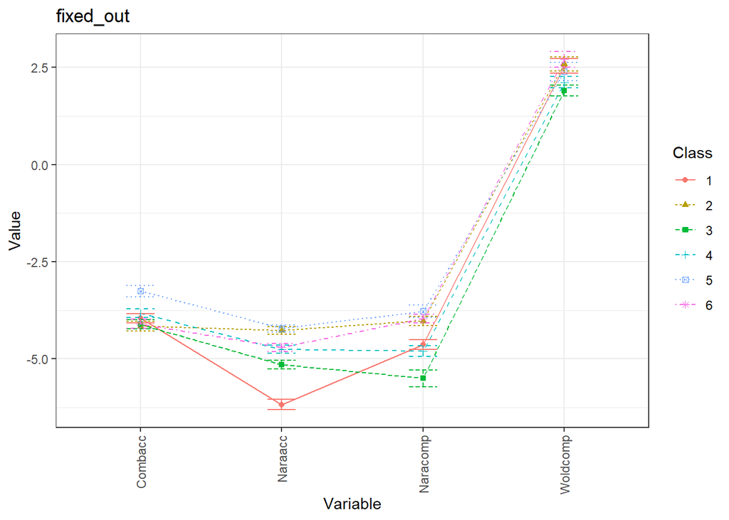

```r
# Plot class means
plotMixtures_simpView(fixed_out)
```

## Step 2A: Compare fit of fixed and freely estimated parameter models

Fit the model to subsample B, allowing parameters to be freely estimated.

```r
free_model <- mplusObject(
  TITLE = "LPA: Confirmatory model (subB free estimation)",
  ANALYSIS = "estimator = mlr; type = mixture; starts = 2000 200;
              processors = 4(STARTS); STSCALE = 1;",
  VARIABLE = "idvariable = cidB3153; classes = c(6);",
  MODEL = loopReplace("
    %OVERALL%
      f8age; f9age;
      combAcc naraAcc naraComp on f9age;
      woldcomp on f8age;

    naraComp combAcc woldComp naraAcc;

    [naraComp naraAcc combAcc woldComp];
    combAcc naraAcc naraComp woldComp ON G;

    naraComp with naraAcc@0;
    naraComp with combAcc@0;
    naraComp with woldComp@0;
    naraAcc with combAcc@0;
    naraAcc with woldComp@0;
    combAcc with woldComp@0;

  %c#1%
     [naraComp naraAcc combAcc woldComp];
     naraComp naraAcc combAcc woldComp;

  %c#2%
     [naraComp naraAcc combAcc woldComp];
     naraComp naraAcc combAcc woldComp;

  %c#3%
     [naraComp naraAcc combAcc woldComp];
     naraComp naraAcc combAcc woldComp;

  %c#4%
     [naraComp naraAcc combAcc woldComp];
     naraComp naraAcc combAcc woldComp;

  %c#5%
     [naraComp naraAcc combAcc woldComp];
     naraComp naraAcc combAcc woldComp;

  %c#6%
     [naraComp naraAcc combAcc woldComp];
     naraComp naraAcc combAcc woldComp;

", named_params),
  OUTPUT = "TECH1 TECH8 TECH11 stdyx CINTERVAL ENTROPY;",
  PLOT = "TYPE = PLOT3;",
  usevariables = colnames(g_data[,!names(g_data) %in% c("yp_id")]),
  rdata = g_data,
  SAVEDATA = "FILE IS free.dat; SAVE = cprobabilities;")

free_results <- mplusModeler(free_model, "mplus_models/simpview/shape/crossval/free.dat", run = FALSE)
```

Compare overall model fit from the fixed and freely estimated models.

```r
# Use readModels to create extract all info for both models
all_mods <- readModels("./mplus_models/simpview/shape/crossval")

compareModels(all_mods[["fixed.out"]], all_mods[["free.out"]],
              show = c("summaries"),
              diffTest = TRUE)
```

```
##
## ==============
##
## Mplus model comparison
## ----------------------
##
## ------
## Model 1:  ./mplus_models/simpview/shape/crossval/fixed.out
## Model 2:  ./mplus_models/simpview/shape/crossval/free.out
## ------
##
## Model Summary Comparison
## ------------------------
##
##              m1
## Title        LPA: Confirmatory model (subB fixed
##                parameters)
## Observations 3423
## Estimator    MLR
## Parameters   47
## LL           -44683.864
## AIC          89461.728
## BIC          89750.227
##              m2
## Title        LPA: Confirmatory model (subB free
##                estimation)
## Observations 3423
## Estimator    MLR
## Parameters   76
## LL           -44161.679
## AIC          88475.359
## BIC          88941.867
##
##   MLR Chi-Square Difference Test for Nested Models Based on Loglikelihood
##   -----------------------------------------------------------------------
##
##   Difference Test Scaling Correction:  2.053303
##   Chi-square difference:  508.6292
##   Diff degrees of freedom:  29
##   P-value:  0
##
##   Note: The chi-square difference test assumes that these models are nested.
##   It is up to you to verify this assumption.
##
##   MLR Chi-Square Difference test for nested models
##   --------------------------------------------
##
##   Difference Test Scaling Correction:
##   Chi-square difference:
##   Diff degrees of freedom:
##   P-value:
##
## Note: The chi-square difference test assumes that these models are nested.
##   It is up to you to verify this assumption.
##
## ==============
```

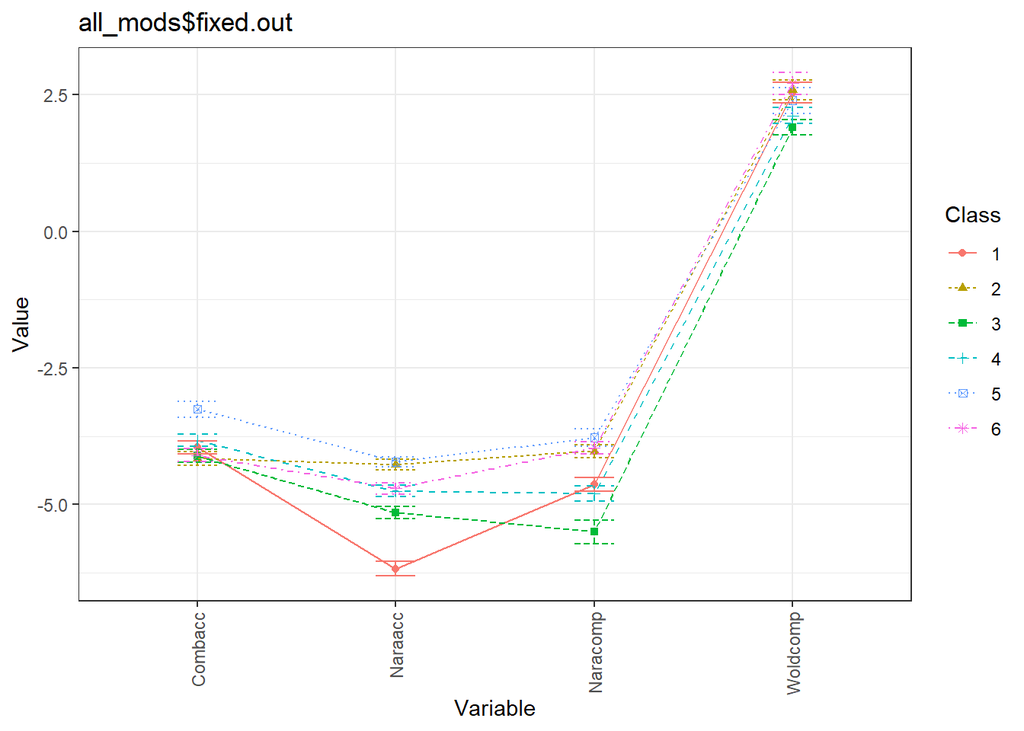

```r
plotMixtures_simpView(all_mods$fixed.out)
```

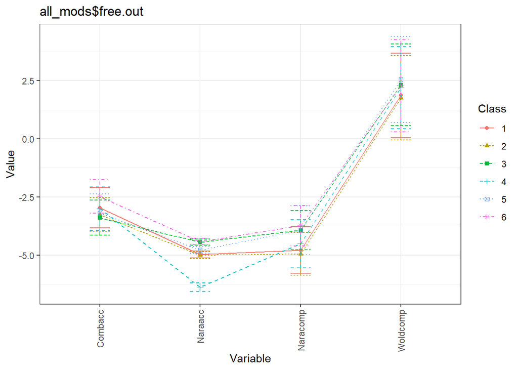

```r
plotMixtures_simpView(all_mods$free.out)
```

*The models estimated with free versus fixed parameters significantly differ in model fit, although the shape of the profiles look reassuringly similar across the two models.*

*Given difference in model fit, model selection was repeated independently with subsample B to ensure the same model was selected (WP1_SimpView_LPA_shapeB.Rmd).*

# B: Cross-validation of model from subsample B

## Set-up

### Read in final model from subsample B

Read in selected model file that contains class assignment data, and data file of descriptive statistics. Merge and check.

```r
# Read in and extract class data
final_mod_B <- readModels(target = "./mplus_models/simpview/shapeB", filefilter = "lpa4_rerun_6class")  # final model file
```

### Load in subsample A data

```r
data_A <- read.csv("../data/processed/WP1_data_subA.csv")  %>%        # ALSPAC data sub A
  dplyr::select(yp_id, cidB3153, age_m_f8, age_m_f9,
                nara_acc_raw_f9, read_word_raw_f9, read_nonw_raw_f9,  # reading accuracy variables
                nara_comp_raw_f9, wold_comp_raw_f8) %>%               # comprehension variables
  mutate(combAcc = read_word_raw_f9 + read_nonw_raw_f9) %>%           # create combined single item accuracy score
  select(-read_word_raw_f9, -read_nonw_raw_f9) %>%                    # remove other measures
  rename(naraComp = nara_comp_raw_f9,                                 # rename within mplus character limit
         naraAcc = nara_acc_raw_f9,
         woldComp = wold_comp_raw_f8,
         f8age = age_m_f8,
         f9age = age_m_f9) %>%
  mutate(yp_id = as.factor(yp_id))
```

### Extract factor scores from CFA model

```r
# Load in scores from previously fitted CFA model, and check model
cfa_out_A <- readModels(target = "./mplus_models/simpview/shape", filefilter = "cfa_scores2")
SummaryTable(cfa_out_A, keepCols = c("Title", "Parameters", "LL", "CFI", "TLI", "AIC", "BIC", "RMSEA_Estimate", "RMSEA_pLT05", "SRMR")) %>% kable("pipe")
```

| Title | Parameters | LL | CFI | TLI | AIC | BIC | RMSEA_Estimate | RMSEA_pLT05 | SRMR |
| --- | --- | --- | --- | --- | --- | --- | --- | --- | --- |
| Confirmatory Factor Analysis - modification1 comprehension tasks; | 24 | -56136.23 | 0.999 | 0.997 | 112320.5 | 112467.8 | 0.021 | 0.996 | 0.006 |

```r
# Extract scores for analysis
g_data_A <- as.data.frame(cfa_out_A$savedata) %>%
  select(-G_SE)
```

## Step 1B: Evaluate model with fixed parameters from subsample B

Extract model parameter estimates from final model selected in exploratory class enumeration process on subsample B (WP1_SimpView_LPA_shape_B.Rmd).

```r
params_B <- final_mod_B$parameters
df_params_B <- data.frame(params_B[[1]]$paramHeader,params_B[[1]]$param, params_B[[1]]$est, params_B[[1]]$LatentClass)
names(df_params_B) <- c("header", "param", "est", "class")

named_params_B <- df_params_B %>%
  mutate(parameter_name = paste(header, param, class, sep = "_")) %>%
  select(-c(header, param, class)) %>%
  pivot_wider(names_from = parameter_name, values_from = est)
```

```r
fixed_model_B <- mplusObject(
  TITLE = "LPA: Confirmatory model (subB fixed parameters)",
  ANALYSIS = "estimator = mlr; type = mixture; starts = 2000 200;
              processors = 4(STARTS); STSCALE = 1;",
  VARIABLE = "idvariable = cidB3153; classes = c(6);",
  MODEL = loopReplace("
  %OVERALL%
      f8age; f9age;
      combAcc naraAcc naraComp on f9age;
      woldcomp on f8age;

    naraComp combAcc woldComp naraAcc ;

    [naraComp naraAcc combAcc woldComp];
    combAcc naraAcc naraComp woldComp ON G;

    naraComp with naraAcc@0;
    naraComp with combAcc@0;
    naraComp with woldComp@0;
    naraAcc with combAcc@0;
    naraAcc with woldComp@0;
    combAcc with woldComp@0;

  [c#1@[[Means_C#1_Categorical.Latent.Variables]]];
  [c#2@[[Means_C#2_Categorical.Latent.Variables]]];
  [c#3@[[Means_C#3_Categorical.Latent.Variables]]];
  [c#4@[[Means_C#4_Categorical.Latent.Variables]]];
  [c#5@[[Means_C#5_Categorical.Latent.Variables]]];

  %c#1%
     [naraComp@[[Intercepts_NARACOMP_1]]];
     [naraAcc@[[Intercepts_NARAACC_1]]];
     [combAcc@[[Intercepts_COMBACC_1]]];
     [woldComp@[[Intercepts_WOLDCOMP_1]]];
     naraComp naraAcc combAcc woldComp;

  %c#2%
     [naraComp@[[Intercepts_NARACOMP_2]]];
     [naraAcc@[[Intercepts_NARAACC_2]]];
     [combAcc@[[Intercepts_COMBACC_2]]];
     [woldComp@[[Intercepts_WOLDCOMP_2]]];
     naraComp naraAcc combAcc woldComp;

  %c#3%
     [naraComp@[[Intercepts_NARACOMP_3]]];
     [naraAcc@[[Intercepts_NARAACC_3]]];
     [combAcc@[[Intercepts_COMBACC_3]]];
     [woldComp@[[Intercepts_WOLDCOMP_3]]];
     naraComp naraAcc combAcc woldComp;

  %c#4%
     [naraComp@[[Intercepts_NARACOMP_4]]];
     [naraAcc@[[Intercepts_NARAACC_4]]];
     [combAcc@[[Intercepts_COMBACC_4]]];
     [woldComp@[[Intercepts_WOLDCOMP_4]]];
     naraComp naraAcc combAcc woldComp;

  %c#5%
     [naraComp@[[Intercepts_NARACOMP_5]]];
     [naraAcc@[[Intercepts_NARAACC_5]]];
     [combAcc@[[Intercepts_COMBACC_5]]];
     [woldComp@[[Intercepts_WOLDCOMP_5]]];
     naraComp naraAcc combAcc woldComp;

  %c#6%
     [naraComp@[[Intercepts_NARACOMP_6]]];
     [naraAcc@[[Intercepts_NARAACC_6]]];
     [combAcc@[[Intercepts_COMBACC_6]]];
     [woldComp@[[Intercepts_WOLDCOMP_6]]];
     naraComp naraAcc combAcc woldComp;

  ", named_params_B),
  OUTPUT = "TECH1 TECH8 TECH11 TECH14 stdyx CINTERVAL ENTROPY;",
  PLOT = "TYPE = PLOT3;",
  usevariables = colnames(g_data_A[,!names(g_data_A) %in% c("yp_id")]),
  rdata = g_data_A,
  SAVEDATA = "FILE IS fixed.dat; SAVE = cprobabilities;")

fixed_results_B <- mplusModeler(fixed_model_B, "mplus_models/simpview/shapeB/crossval/fixed.dat", run = FALSE)
```

Inspect model output

```r
# Read in output
fixed_out_B <- readModels(target = "./mplus_models/simpview/shapeB/crossval", filefilter = "fixed")

# Print table
fixed_out_summary_B <- lpa_enum_table(output = fixed_out_B)
fixed_out_summary_B %>% kable("pipe")
```

| Specification | Classes | LL | Parameters | BIC | CAIC | AWE | VLMR_p | LMR_p | BF | cmP_k |
| --- | --- | --- | --- | --- | --- | --- | --- | --- | --- | --- |
| LPA: Confirmatory model (subB fixed parameters) | 6 | -42992.72 | 47 | 86367.93 | 86414.93 | 86438.43 | 0.01 | 0.01 | NA | 1 |

```r
# Compute classification diagnostics
class_diag(fixed_out_B)
```

```
## [1] "CLASSIFICATION DIAGNOSTICS FOR  LPA: CONFIRMATORY MODEL (SUBB FIXED PARAMETERS)"
## [1] "Entropy: 0.759"
##
## [1] "Average posterior class probability:"
##     1     2     3     4     5     6
## 0.797 0.854 0.861 0.765 0.836 0.831
##
## [1] "Odds of correct classification ratio:"
##  1  2  3  4  5  6
## 16 19 28 18 68 24
## [1] "Good class separation and assignment accuracy (Nagin, 2005)"
##
## [1] "Model estimated proportion for each class:"
## [1] 0.19810 0.23155 0.17889 0.15229 0.07002 0.16915
##
## [1] "Proportion modally assigned to each class:"
## [1] 0.11861 0.29740 0.20947 0.09056 0.06369 0.22027
##
## [1] "--------------------------------------------"
```

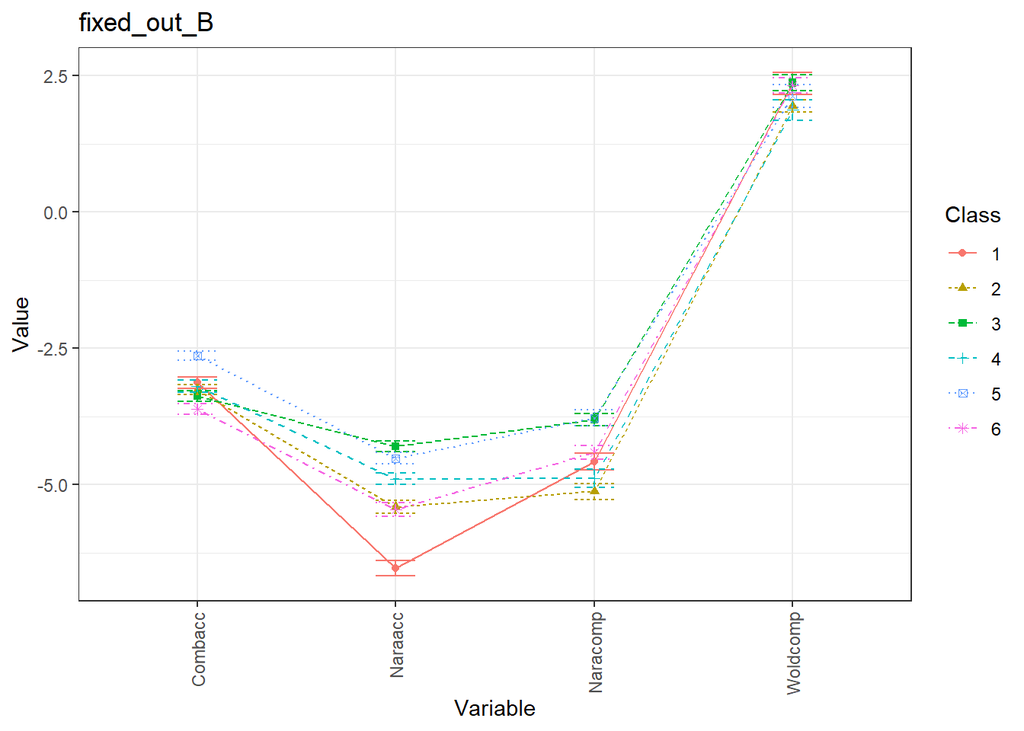

```r
# Plot class means
plotMixtures_simpView(fixed_out_B)
```

## Step 2B: Compare fit of fixed and freely estimated parameter models

```r
compareModels(final_mod, fixed_out_B,
              show = c("summaries"),
              diffTest = TRUE)
```

```
##
## ==============
##
## Mplus model comparison
## ----------------------
##
## ------
## Model 1:  ./mplus_models/simpview/shape/sv_lpa4_rerun_6class.out
## Model 2:  ./mplus_models/simpview/shapeB/crossval/fixed.out
## ------
##
## Model Summary Comparison
## ------------------------
##
##              m1        m2
## Title                  LPA: Confirmatory model (subB fixed
##                          parameters)
## Observations 3423      3423
## Estimator    MLR       MLR
## Parameters   76        47
## LL           -42129.85 -42992.716
## AIC          84411.7   86079.431
## BIC          84878.209 86367.93
##
##   MLR Chi-Square Difference Test for Nested Models Based on Loglikelihood
##   -----------------------------------------------------------------------
##
##   Difference Test Scaling Correction:  1.736659
##   Chi-square difference:  993.7083
##   Diff degrees of freedom:  29
##   P-value:  0
##
##   Note: The chi-square difference test assumes that these models are nested.
##   It is up to you to verify this assumption.
##
##   MLR Chi-Square Difference test for nested models
##   --------------------------------------------
##
##   Difference Test Scaling Correction:
##   Chi-square difference:
##   Diff degrees of freedom:
##   P-value:
##
## Note: The chi-square difference test assumes that these models are nested.
##   It is up to you to verify this assumption.
##
## ==============
```

Perhaps unsurprisingly, the fixed and freely estimated models again show a statistically significant difference in fit. This looks to be largely due to the difference in intercepts for each profile, whereas the shape of the profiles look relatively stable.

# Full data model

## Fit final model to full dataset

Fit the selected final model to the full dataset.

```r
data_all <- read.csv("../data/processed/WP1_data_all.csv")  %>%       # ALSPAC data
  dplyr::select(yp_id, cidB3153, age_m_f8, age_m_f9,
                nara_acc_raw_f9, read_word_raw_f9, read_nonw_raw_f9,  # reading accuracy variables
                nara_comp_raw_f9, wold_comp_raw_f8,                   # comprehension variables
                ethn_white, m_age_birth, m_home_own, m_edu_alev) %>%  # auxiliary variables
  mutate(combAcc = read_word_raw_f9 + read_nonw_raw_f9) %>%           # create combined single item accuracy score
  select(-read_word_raw_f9, -read_nonw_raw_f9) %>%                    # remove other measures
  rename(naraComp = nara_comp_raw_f9,
         naraAcc = nara_acc_raw_f9,
         woldComp = wold_comp_raw_f8,
         f8age = age_m_f8,
         f9age = age_m_f9,
         ethn = ethn_white,
         mAge = m_age_birth,
         home = m_home_own,
         mEdu = m_edu_alev) %>%
  mutate(yp_id = as.factor(yp_id))
```

```r
# Run single factor model (including age covariates)
m_cfa <- mplusObject(
  TITLE = "Confirmatory Factor Analysis - Extract factor scores;",
  ANALYSIS = "estimator = mlr; type = general;",
  MODEL = "f8age; f9age;
           G by combAcc naraAcc naraComp woldComp;
           woldComp with naraComp;
           combAcc naraAcc naraComp on f9age;
           woldComp on f8age;",
  VARIABLE = "idvariable = cidB3153;",
  OUTPUT = "sampstat; TECH1; TECH4; stdyx; modindices; ",
  PLOT = "TYPE = PLOT3;",
  usevariables = c("cidB3153", "naraComp", "naraAcc", "combAcc", "woldComp", "f8age", "f9age"),
  rdata = data_all,
  SAVEDATA = "FILE IS cfa_full.dat; SAVE = fscores;")

m_cfa_fit <- mplusModeler(m_cfa,
                           modelout = "./mplus_models/simpview/final_model/cfa_full.inp",
                           check = TRUE, run = FALSE)
```

```
## The following lines are longer than 90 characters
## 4: FILE = "./mplus_models/simpview/final_model/cfa_full_dd0074179903a02528803ae52aecc878.dat";
```

```
## Mplus will ignore everything after the 90th character on a line.
## Consider breaking the line(s)
```

```r
# Inspect model output
cfa_full <- readModels(target = "./mplus_models/simpview/final_model", filefilter = "cfa_full")
SummaryTable(cfa_full, keepCols = c("Title", "Parameters", "LL", "CFI", "TLI", "AIC", "BIC", "RMSEA_Estimate", "RMSEA_pLT05", "SRMR")) %>% kable("pipe")
```

| Title | Parameters | LL | CFI | TLI | AIC | BIC | RMSEA_Estimate | RMSEA_pLT05 | SRMR |
| --- | --- | --- | --- | --- | --- | --- | --- | --- | --- |
| Confirmatory Factor Analysis - Extract factor scores; | 24 | -112748.3 | 0.999 | 0.996 | 225544.5 | 225708.5 | 0.026 | 0.999 | 0.006 |

```r
# Extract scores for analysis
g_full <- as.data.frame(cfa_full$savedata) %>%
  select(CIDB3153, G)

data_all <- data_all %>%
  left_join(g_full, by = c("cidB3153" = "CIDB3153"))
```

```r
full_model <- mplusObject(
 TITLE = "LPA with covariate: Final model full dataset",
  ANALYSIS = "estimator = mlr; type = mixture; starts = 2000 200;
              processors = 4(STARTS); STSCALE = 1;",
  VARIABLE = "idvariable = cidB3153; classes = c(6);",
  MODEL =
    "%OVERALL%
      f8age; f9age;
      combAcc naraAcc naraComp on f9age;
      woldcomp on f8age;

    naraComp combAcc woldComp naraAcc;

    [naraComp naraAcc combAcc woldComp];
    combAcc naraAcc naraComp woldComp ON G;

    naraComp with naraAcc@0;
    naraComp with combAcc@0;
    naraComp with woldComp@0;
    naraAcc with combAcc@0;
    naraAcc with woldComp@0;
    combAcc with woldComp@0;

  %c#1%
     [naraComp naraAcc combAcc woldComp];
     naraComp naraAcc combAcc woldComp;

  %c#2%
     [naraComp naraAcc combAcc woldComp];
     naraComp naraAcc combAcc woldComp;

  %c#3%
     [naraComp naraAcc combAcc woldComp];
     naraComp naraAcc combAcc woldComp;

  %c#4%
     [naraComp naraAcc combAcc woldComp];
     naraComp naraAcc combAcc woldComp;

  %c#5%
     [naraComp naraAcc combAcc woldComp];
     naraComp naraAcc combAcc woldComp;

  %c#6%
     [naraComp naraAcc combAcc woldComp];
     naraComp naraAcc combAcc woldComp;",
  OUTPUT = "TECH1 TECH8 stdyx CINTERVAL ENTROPY;",
  PLOT = "TYPE = PLOT3;",
  usevariables = colnames(data_all[,!names(data_all) %in% c("yp_id", "ethn", "mAge", "home", "mEdu")]),
  rdata = data_all,
  SAVEDATA = "FILE IS lpa_full.dat; SAVE = cprobabilities;")

full_results <- mplusModeler(full_model, "mplus_models/simpview/final_model/lpa_full.dat", run = FALSE)
```

## Final model parameters

```r
readModels("mplus_models/simpview/final_model/lpa_full.out", what="parameters")$parameters$r2 %>% kable("pipe")
```

| param | est | se | est_se | pval | LatentClass |
| --- | --- | --- | --- | --- | --- |
| NARAACC | 0.999 | 0.000 | 4990.177 | 0 | 1 |
| NARACOMP | 0.826 | 0.025 | 32.702 | 0 | 1 |
| WOLDCOMP | 0.123 | 0.013 | 9.799 | 0 | 1 |
| COMBACC | 0.712 | 0.016 | 44.359 | 0 | 1 |
| NARAACC | 1.000 | 0.000 | ******** | 0 | 2 |
| NARACOMP | 0.927 | 0.005 | 186.986 | 0 | 2 |
| WOLDCOMP | 0.160 | 0.014 | 11.416 | 0 | 2 |
| COMBACC | 0.924 | 0.007 | 128.315 | 0 | 2 |
| NARAACC | 0.999 | 0.000 | 9203.454 | 0 | 3 |
| NARACOMP | 0.702 | 0.013 | 52.333 | 0 | 3 |
| WOLDCOMP | 0.076 | 0.007 | 10.385 | 0 | 3 |
| COMBACC | 0.766 | 0.017 | 45.705 | 0 | 3 |
| NARAACC | 1.000 | 0.000 | ******** | 0 | 4 |
| NARACOMP | 0.926 | 0.007 | 132.702 | 0 | 4 |
| WOLDCOMP | 0.118 | 0.010 | 11.278 | 0 | 4 |
| COMBACC | 0.916 | 0.007 | 138.928 | 0 | 4 |
| NARAACC | 1.000 | 0.000 | ******** | 0 | 5 |
| NARACOMP | 0.923 | 0.005 | 171.965 | 0 | 5 |
| WOLDCOMP | 0.112 | 0.011 | 10.235 | 0 | 5 |
| COMBACC | 0.920 | 0.006 | 157.961 | 0 | 5 |
| NARAACC | 0.997 | 0.000 | 2579.736 | 0 | 6 |
| NARACOMP | 0.771 | 0.020 | 37.919 | 0 | 6 |
| WOLDCOMP | 0.137 | 0.014 | 9.538 | 0 | 6 |
| COMBACC | 0.764 | 0.019 | 40.479 | 0 | 6 |

```r
readModels("mplus_models/simpview/final_model/lpa_full.out", what="parameters")$parameters$stdyx.standardized %>% kable("pipe")
```

| paramHeader | param | est | se | est_se | pval | LatentClass |
| --- | --- | --- | --- | --- | --- | --- |
| COMBACC.ON | F9AGE | 0.195 | 0.010 | 18.579 | 0.000 | 1 |
| COMBACC.ON | G | 0.821 | 0.009 | 88.612 | 0.000 | 1 |
| NARAACC.ON | F9AGE | 0.260 | 0.004 | 60.017 | 0.000 | 1 |
| NARAACC.ON | G | 0.965 | 0.001 | 818.918 | 0.000 | 1 |
| NARACOMP.ON | F9AGE | 0.243 | 0.013 | 18.192 | 0.000 | 1 |
| NARACOMP.ON | G | 0.876 | 0.014 | 64.119 | 0.000 | 1 |
| WOLDCOMP.ON | F8AGE | 0.034 | 0.014 | 2.434 | 0.015 | 1 |
| WOLDCOMP.ON | G | 0.349 | 0.018 | 19.548 | 0.000 | 1 |
| NARACOMP.WITH | NARAACC | 0.000 | 0.000 | 999.000 | 999.000 | 1 |
| NARACOMP.WITH | COMBACC | 0.000 | 0.000 | 999.000 | 999.000 | 1 |
| NARACOMP.WITH | WOLDCOMP | 0.000 | 0.000 | 999.000 | 999.000 | 1 |
| NARAACC.WITH | COMBACC | 0.000 | 0.000 | 999.000 | 999.000 | 1 |
| NARAACC.WITH | WOLDCOMP | 0.000 | 0.000 | 999.000 | 999.000 | 1 |
| COMBACC.WITH | WOLDCOMP | 0.000 | 0.000 | 999.000 | 999.000 | 1 |
| F9AGE.WITH | F8AGE | 0.070 | 0.018 | 3.885 | 0.000 | 1 |
| Means | F8AGE | 49.426 | 0.831 | 59.465 | 0.000 | 1 |
| Means | F9AGE | 31.380 | 0.451 | 69.545 | 0.000 | 1 |
| Intercepts | NARAACC | -4.948 | 0.058 | -85.694 | 0.000 | 1 |
| Intercepts | NARACOMP | -5.171 | 0.400 | -12.929 | 0.000 | 1 |
| Intercepts | WOLDCOMP | 1.956 | 0.683 | 2.863 | 0.004 | 1 |
| Intercepts | COMBACC | -3.699 | 0.347 | -10.670 | 0.000 | 1 |
| Variances | F8AGE | 1.000 | 0.000 | 999.000 | 999.000 | 1 |
| Variances | F9AGE | 1.000 | 0.000 | 999.000 | 999.000 | 1 |
| Residual.Variances | NARAACC | 0.001 | 0.000 | 6.631 | 0.000 | 1 |
| Residual.Variances | NARACOMP | 0.174 | 0.025 | 6.887 | 0.000 | 1 |
| Residual.Variances | WOLDCOMP | 0.877 | 0.013 | 69.722 | 0.000 | 1 |
| Residual.Variances | COMBACC | 0.288 | 0.016 | 17.912 | 0.000 | 1 |
| COMBACC.ON | F9AGE | 0.189 | 0.010 | 18.900 | 0.000 | 2 |
| COMBACC.ON | G | 0.943 | 0.004 | 245.769 | 0.000 | 2 |
| NARAACC.ON | F9AGE | 0.222 | 0.004 | 58.834 | 0.000 | 2 |

[output cut: 132 more lines]

# Missing data check

# Version info

*Package versions were up-to-date as of 12/08/2021.* *LPA models were run using Mplus Version 8.5.*